# 開発経済論: 効果推計

Ingenuity of Angrist and Lavy (1999): Predicited class size vs. exam scores.

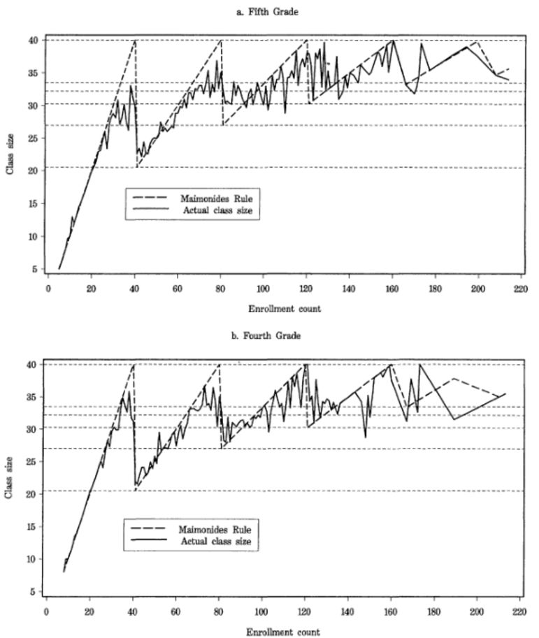

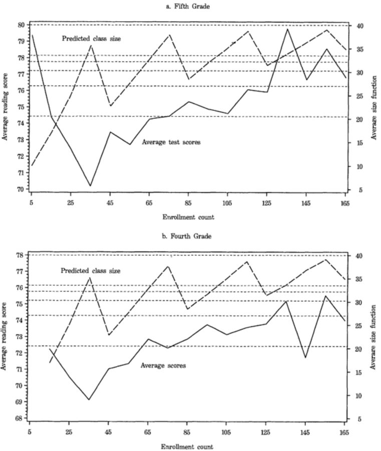

- Impact is more evident in smaller enrollment counts.
- Average score is increasing after 60 regardless of predicted class size.
- Possible reasons: Greater deviation of actual class size from predicted class size, different petagogical methods in large schools or more competition/learning among peers.

推計結果の読み方

$$LHS = a+b_{1}*RHS_{1}+b_{2}*RHS_{2}+\dots+b_{k}*RHS_{k}+e$$

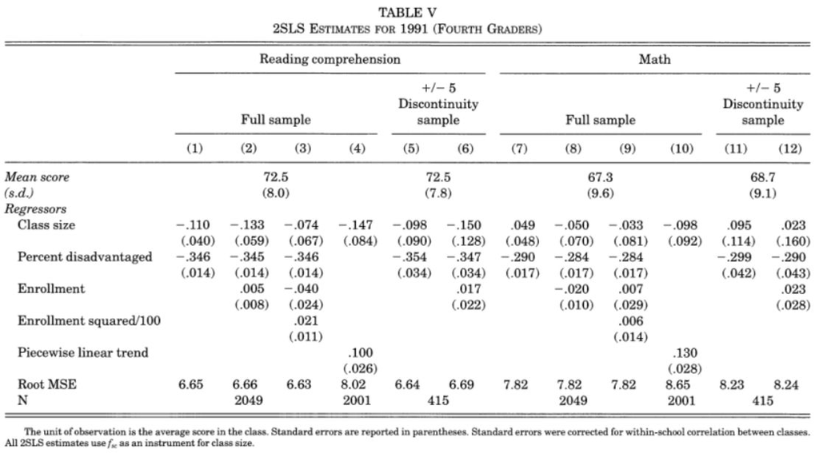

4th graders

Reading comprehension

国語読解の点数

(1)…(6): 6つの推計式

Math

数学の点数

(7)…(12): 6つの推計式

カットオフ=学級サイズが急激に減少する人数(理論値)

**Mean score**

LHS (left hand side左辺) variable変数の平均値

**(S.d.)**

標準偏差standard deviation=LHS変数の散らばり程度

**Regressors**

RHS (right hand side) variablesの係数 ($a, b_{1}, \dots, b_{k}$)

**Class size(学級サイズ=何人)**

推計された係数$b_{1}$

**(括弧内の数字)**

標準誤差、係数の絶対値/標準誤差>1.96であれば$p$値=5%くらい(だと$b_{1}\neq 0$かも)

**Root MSE**

$\sqrt{MSE}$, MSE=mean squared error, 誤差の2乗和$\sum e^{2}_{i}$

**N**

サンプルサイズ

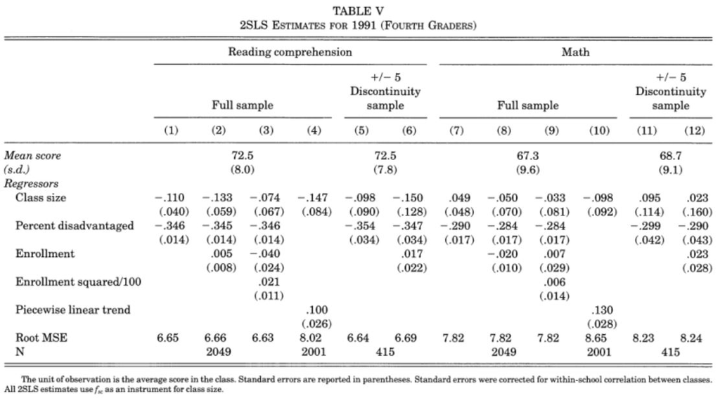

4th graders

- Class size $\SIMneg$ learning, in some specifications of all samples
- For 4th graders, no impacts of class size at discontinuity neighbourhood sample

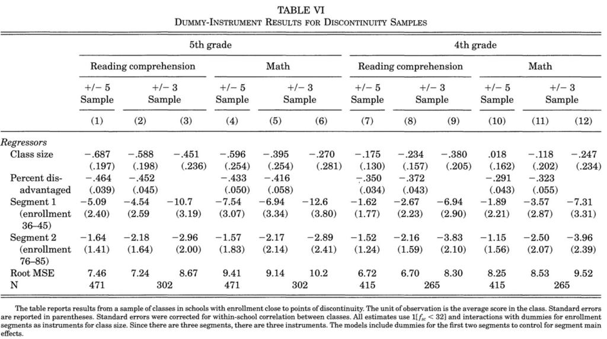

4th and 5th graders, discontinuity samples

- Class size $\SIMneg$ learning, class size $\SIMneg$ math, for 5th graders

横浜市2009年40人学級: 小6国語(共通試験点数偏差値)

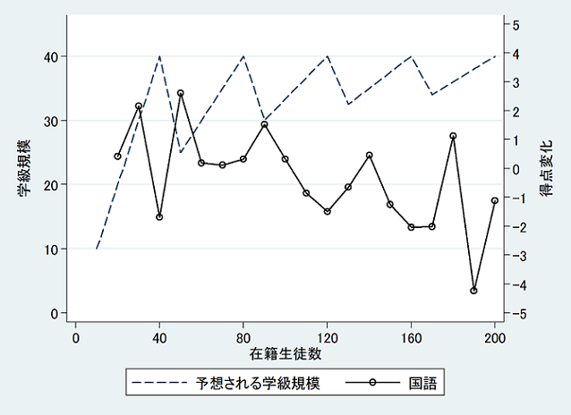

Akabayashi and Nakamura (2014)

横浜市2009年40人学級: 中3国語(共通試験点数偏差値)

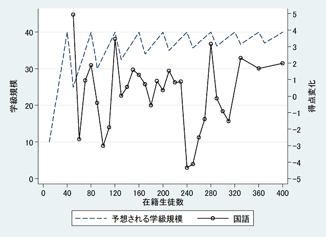

Akabayashi and Nakamura (2014)

赤林さんは中3国語で期待した成果が出なかったことに驚くが、以下のように解釈 https://synodos.jp/education/12530

少人数学級=きめ細やかな指導が可能、なので、自動的に成績が上がるわけではない

教員の指導能力、意欲、効率性重視方針も必要

教員の数が増えれば能力が低い、意欲が弱い人も雇用される

伸び代が高い生徒に注力(効率性重視)するか、成績の低い生徒に注力(公平性重視)するか

- どうも地価の高い地域では成績が上がったようです(論文アクセスないので未読)

情報開示請求で得た学校平均点数と学年生徒数のデータなので、実際のクラス数(よって、実際のクラス・サイズ)は分からない模様

点数がより変化しやすそうな英語や数学の結果が知りたい

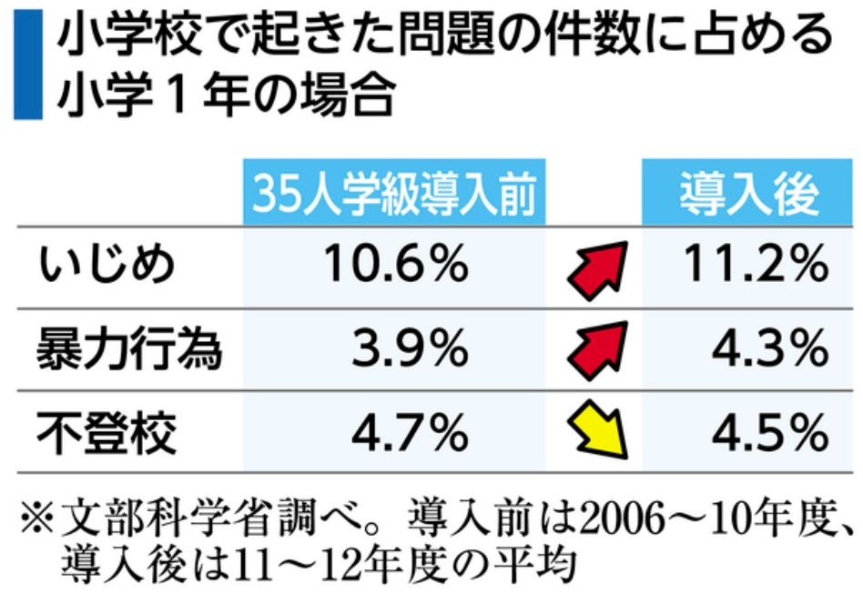

ダイアモンド・オンライン2015年2月18日https://diamond.jp/articles/-/66992

- 割合が増えたか減ったかを見るのは良い
- しかし、その変化が統計学的に意味があるか(=ゼロと違うか)仮説検定していない
- 推計方法(識別仮定)の信頼性が低い
- プラシーボ検定(私立1年生や公立2年生)もできる

中室牧子さん: 35人学級は、2011年に公立小学校の1年生に対してのみ導入されました。財務省は、2011年以前と以後で、いじめ、暴力行為、不登校の平均値を比べると、いじめや暴力、不登校には大きな変化が見られないので、少人数学級には効果がない。したがって、「40人学級に戻すべき」と主張したのです。

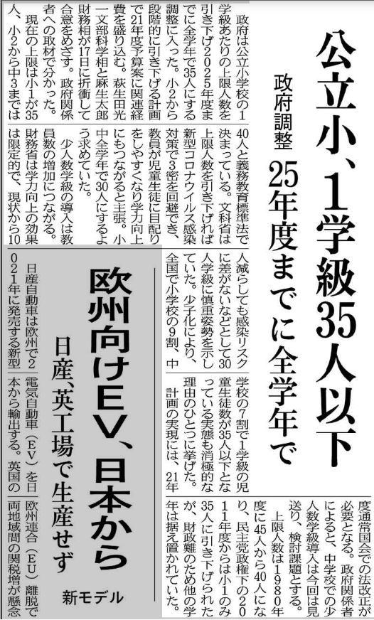

日経新聞2020年12月17日(木)朝刊

- 3密回避が動機
- 今回も(35人が良いとする)エビデンスに依拠せず
- 全国一律だと効果推計は難しい
1. (Lemieux and Milligan 2008) In Quebec (but only in Quebec and not in rest of Canada), from 1969 to August 1989, unemployment benefits are increased once reaching the age of 30 for adults with no child ($185→$507). This should have disincentives to work for age 30 and older. If this is true, at around 30, work outcomes will be reduced.
   - Will there be a jump in employment rates at 30 to the below?
2. (Lee 2008) Being an incumbent can give an additional benefit in the next election. If this is true, at the vote share margin close to zero, an incumbent vs. non-incumbent contrast gives effects of this benefit. Most suitable data comes from the US state gubernatorial elections where there are effectively only two candidates/parties.
   - Will there be a jump in winning probability at zero vote margin to the above?
1. Age and unemployment benefits in Quebec (Lemieux and Milligan 2008)

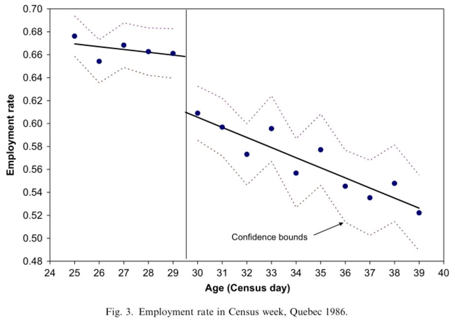

- Unemployment benefits↑ once reaching the age of 30 (with no child).
- Create disincentives to work for age 30 and older?
- If so, at around 30, work outcomes will be reduced.

It is reduced.

2. Margin of vote share in $t$ and probability of winning in $t+1$ (Lee 2008)

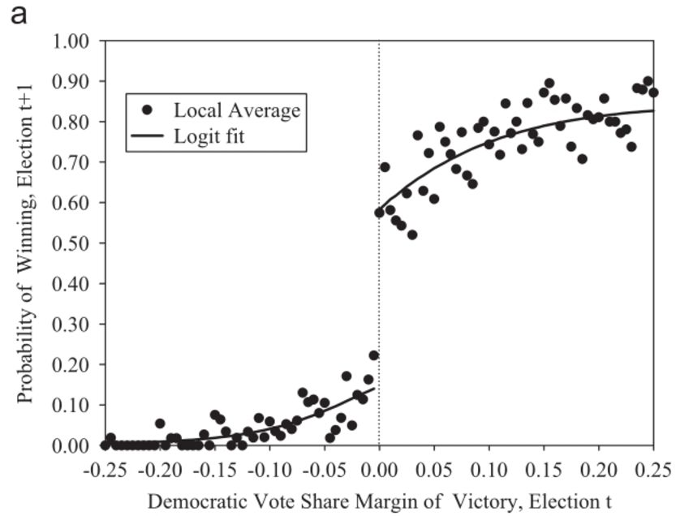

- An incumbent ⇒ additional benefit in the next election
- ⇒ at the vote share margin close to zero, an incumbent vs. non-incumbent contrast = effects of this benefit
- US state gubernatorial elections (effectively only two candidates/parties)

There is an additional benefit

Placebo tests

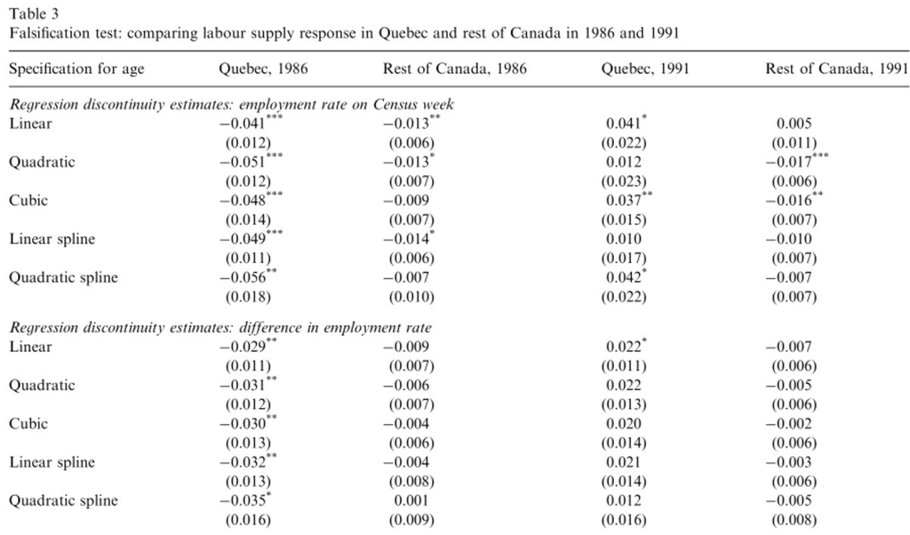

Rest of Canada or post 1991 should not detect effects.

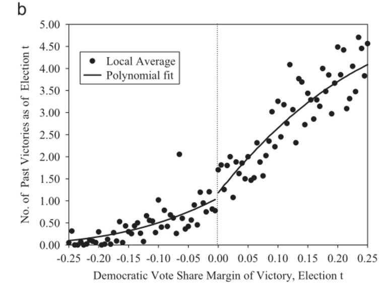

Margin of vote share in $t$ should not give a jump of events before $t$.

なぜRDD推計量は信頼性があるのかWhy RDD estimator is credible

RDDは局地的な実験と捉えられるためBecause RDD can be considered a localised experiment

境界内外で越境があったとしても、treatment assignmentについて人々の意向が不正確にしか反映されなければ、ランダムな割当の要素があるからEven if there are cross-border movements, when the treatment assignment imperfectly reflects people’s intentions, there is an element randomess to it

実験と同様、density testはランダム化を達成できたか検定Just as covariate mean equality tests in an RCT, density test is a test of randomisation

RDD での識別仮定の信頼性チェック

1. Placebo test: 欠落変数の影響を確認: 政策変化のない点の推計値がゼロを検定
   - …棄却(「効果」あり) $\Rightarrow$ 推計した効果に疑問
2. Density test: 非越境(local randomisation)の確認
   - 越境者が多ければ境界で標本が多くなり、分布に凹凸ができる: forcing variableの分布密度が境界内外で等しい(=帰無仮説: 越境がなく分布の差が境界内外でゼロ)か検定(density test or McCary test)
     - …棄却(凸凹あり) $\Rightarrow$ 越境あり
3. Equality test: 非越境(local randomisation)の確認
   - 治療確率(propensity scoreという)の差が境界内外でゼロ(=帰無仮説: 越境が完全で治療確率に対し境界が無意味になる)か検定
     - …棄却(確率異なる) $\Rightarrow$ 境界に意味あり
   - 特定の特徴を持つ人たちが越境していないか: その他変数の平均値が境界内外で等しい(=帰無仮説: 越境がなく平均値の差が境界内外でゼロ)か検定
     - …棄却(特徴異なる) $\Rightarrow$ 境界で棲み分けあり…越境

PTは論理的なチェックで傍証。DT, ETはランダム化の検定。

Density testの例

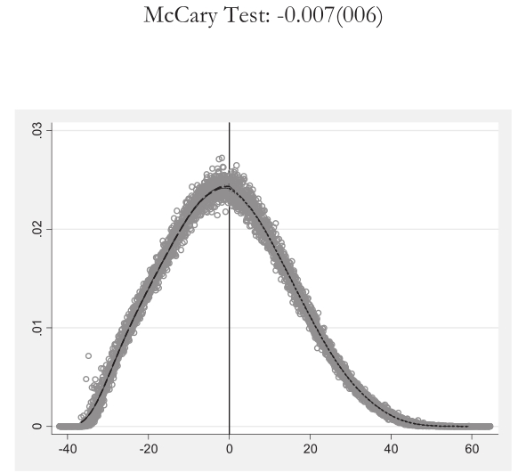

Figure 2, Bosch and Schady (2019)

確率密度は境界でジャンプしていないことが視覚的に分かる(検定結果の統計値は-.007、標準誤差が.006)

識別仮定の信頼性チェック

1. RCT
   - ランダム化の方法: 乱数発生プログラムか?
   - ランダマイゼーション・テスト
     - 並べ替え検定permutation test
     - Mean equality test
2. 自然実験
   - Falsification/Placebo test: 介入があり得ない対象で効果はあるか?
3. RDD
   - Density test
   - Propensity score test
   - Falsification/Placebo test: 介入があり得ない対象で効果はあるか?

識別仮定の信頼性チェック

4. Synthetic control method
   - Robustness checks
     - Use different donor pools
     - Use different donor selection algorithm
   - Falsification/Placebo test: 介入があり得ない対象(pre-period)で効果はあるか?
5. DID, event study design
   - Pre-trend test
   - Falsification/Placebo test: 介入があり得ない対象(pre-period)で効果はあるか?
   - (Estimate “honest” DID with pre-trend, Rambachan and Roth (2023) )
   - (Estimate synthetic-DID, Arkhangelsky et al. (2021) )

# Synthetic control method

国や(関東など大きな)地方単位でインパクトを推計したいときもある

- 社会科学分野の政策は大きな単位で実施することが多い。貿易自由化、経済自由化、アベノミクス、量的金融緩和政策、マイナス金利など。
- 問題: 統御群(CFとなる国や地方)がない。インパクト評価の手法を使えない。
  - マクロ経済学: マクロ経済モデル(マクロ経済を表す数理統計モデル、$Y=a+bX+e$が複数ある連立方程式)を作り、データを使ってモデルのパラメタ$a, b$を推計し、推計値$\hat{a},\hat{b}$をモデルに代入して影響を計算$Y_{1}=\hat{a}+\hat{b}X_{1}$する。
  - CFはモデルで作っている。金利を下げると銀行貸出が(下げなかったときよりも)増えて企業の投資が(下げなかったときよりも)増え…などという設定は、CF(金利を下げなかったとき)との比較で示されている。$\hat{a},\hat{b}$やモデル正しい?
- SCMはCFなしに効果推計をします
- なので、用いている仮定が満たされるのか、相当怪しい場合もあります

2020年12月14日(月)GoToトラベル全国一斉一時停止

[figure not shown]

FNNプライムニュース2020年11月25日(水)

エビデンス=科学的な方法で明らかになった事象

科学的な方法: 反証可能な命題が成立するか検定する方法

「GoToトラベルやって感染拡大を絶対招いちゃったけど、エビデンスはないから」

エビデンスがないのは事実

- 政府は効果検証用にデータを収集していないため
- 検証するつもりなし、と言っているに等しい

利用可能なデータを前提にすると、どのような効果検証が可能か?

2020年12月14日(月)GoToトラベル全国一斉一時停止

http://www.kantei.go.jp/jp/99_suga/statement/2022/1214kaiken02.html

記者「GoToトラベルに感染拡大のエビデンスがないとの認識はあったか?」

(NHKサイトでは「GoToトラベルに感染拡大のエビデンスはないという認識は変わったのか」)

管首相

「そこは、医師会の会長が申し上げているのではないでしょうか。それと、当時は移動によっては、感染を拡大しないということ、ここも提言もあります。そこについては変わりません。ただ、今回そうしたことの専門家の委員の先生方からそういう指摘をいただきましたので、この3000人、現実的に患者の方が出ていますから、年末年始、集中的に対応できる、そういうチャンスだと、そういう思いの中で私は判断しました。」

エビデンスはなく(と会長が言っているだけで自分は言ってない)、移動は感染を広げないと(誰から?)聞いていたが、感染者数が増えたから停止、という主張

2020年12月14日(月)GoToトラベル全国一斉一時停止

2020年11月18日(水)日本医師会会長中川氏

「GoToトラベル自体から感染者が急増したというエビデンス（根拠）はなかなかはっきりしないが、きっかけになったことは間違いないと私は思っている。感染者が増えたタイミングを考えると関与は十分しているだろう」

- 原因ではないがきっかけ、というのは意味不明

2020年12月16日(水)衆院内閣閉院中審査: 新型コロナウィルス感染症対策分科会会長尾身氏

「50歳以下の人が移動して二次感染を起こしていることがはっきりしきたので、人の動きを止めることが重要で、その一環のなかでGoToトラベル(一時停止)もある」「本質は意図せず重症化が出るので、そのような文脈のなかでGoToトラベルも考えるべきと再三申し上げている」

- 「移動は感染を拡大させない」という提言はない
- 50歳以下が感染伝播の高リスク・グループと判明、この移動を制限すべき、と提言
  - GoToトラベルによる感染拡大のエビデンスはないが、論理的帰結によって制限を結論

効果推計の例

- 旅客人数: 前年度同月値との比較
- 旅行支出: 推計した需要関数が正しいと前提に補助金の効果を試算
- (有症率比較: GoToトラベル利用者 vs. 非利用者)
- ビッグ・データによる人の移動: GoToトラベル開始前後の変化-昨年同時期の変化
- グレンジャー因果性: 航空旅行客と感染者数の関係
- 合成統御法: GTT東京追加と東京圏感染者数の関係

よくある比較

GoToトラベル実施月の旅客人数を前年度同月値と比較して「x%多かった」と示す

昨年度と比較=GoToトラベルなしだと昨年と同じという(暗黙の?)仮定をしている

**被説明変数**

旅客人数

**データ**

国土交通省データ

**識別仮定identification assumption**

「GoToトラベルがなければ、今年も昨年と同じ人の移動だった」

このデザインでの効果推計値の信頼性=この識別仮定の現実妥当性

課題

1. GoToトラベルなしのとき、移動人数が当該年と前年で同じと期待する理由はない。おそらく、GoToトラベル実施年はCOVID-19によって景気後退していたので旅客需要は減っていて、GoToトラベルなしだとその前年より少なかったはず。
   - 「分母」=過大評価された比較対象=なしのときの水準を過大に設定している
   - 効果を過小評価=“conservative” estimate
2. 2020年(GoToトラベル実施時)に入国制限されたインバウンド客を除外して2019年のデータを作成できるか?

誰にでもできる分析なので、何と比較すべきかを考えずにやっている人が多いはず

「今年はコロナウィルス流行によって大きく減っているという事情はありますが」などと、景気後退の影響について数字以外の補正をして説明するはず

効果があったのかはっきりしないし、聞き手の主観が入り込む

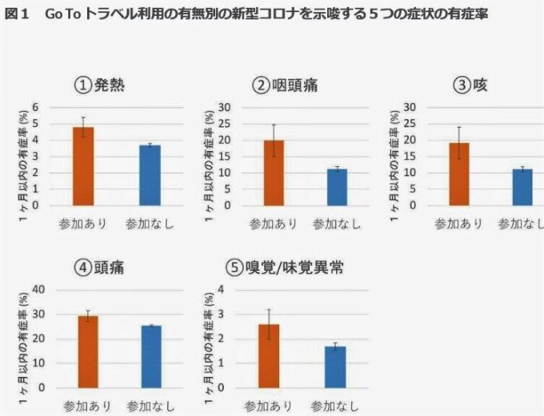

論文: Miyawaki et al. (2020)

「GoToトラベル利用者感染リスク高い」東京大学など研究チーム

2020年12月8日(火)

「GoToトラベル利用者感染リスク高い」東京大学など研究チーム

研究デザイン

- インターネット調査(楽天インサイト社実施)、22万4389人中2万8000人回答、2万5482人有効回答
- 症状有無、GoToトラベル利用有無、社会経済変数、既往症

解釈: 以下の可能性がある

1. GoToトラベルで罹患
2. 有症率(=罹患確率)の高い人がGoToトラベル利用

結論: 「リスクの低い人に経済活動の誘因を与え、高い人は自宅待機を促すべき」

「GoToトラベル利用者感染リスク高い」東京大学など研究チーム

閣僚の反応

https://news.tbs.co.jp/newseye/tbs_newseye4146048.htm?1607587275057

**田村憲久厚労相**

「ちょっとエビデンスといえるものなのかどうなのか、ちょっと査読も終わっていないという話ですし。評価のしようがないというのが、正直なところでありますので」

**赤羽一嘉国交相**

「この論文についても、ちょっと正式に査読前という話もありましたし。現時点では全くコメントする段階でないと思っている」

- 査読通ったら意見、対応するのか?

**加藤勝信官房長官**

「著者自らもですね、研究方法の限界として、GoToトラベルの利用が直接的に新型コロナ症状の増加につながったという因果関係は断定できないこと」

- 実験は存在しないので因果関係は示せない。では、どんな事実があれば対応するのか?エビデンスなんて出てこないことを知っていながらの、何もしない言い訳では?
- 単にケチ付けているだけでは?

「GoToトラベル利用者感染リスク高い」東京大学など研究チーム

示した解釈が面白いし、明確な政策提言になっている

結果の提示も慎重「因果関係を示している訳ではない」

しかし… この研究には方法論として弱点があると思います  
何でしょうか?

「GoToトラベル利用者感染リスク高い」東京大学など研究チーム

示したこと: 有症率(A)とGoToトラベル利用(B)の正の相関

検討していない可能性: みせかけの相関

その他の現象(C)が(A)と(B)を同時に動かしているのでは?

Cの例: 外出量

外出好きな人は罹患確率[$\propto$有症率(A)]が高い

⇒ 外出好きな人は旅行をよくする(行くのだったら割引を使う)

⇒ 外出好きな人は罹患しやすく、旅行も頻繁にする、というだけでは?

もしもそうだったら、結論は常識の範囲内

「GoToトラベル利用者感染リスク高い」東京大学など研究チーム

政策提言が実施困難: どうやって個人の感染させるリスクを判断するのか?

年齢: 年齢差別になりかねず、違憲の可能性あり

もしも可能だったら…ランダムにGoToトラベル資格を配布する実験をする

有資格者と無資格者の有症率の違いを検定する: 明確な因果関係

でも、有資格者と周辺者が危険に曝される可能性があるので、研究倫理審査委員会が却下するかも

GoToトラベル=研究倫理審査委員会が却下しかねない政策

「GoToトラベル利用者感染リスク高い」東京大学など研究チーム

普段の外出頻度を尋ねていれば、外出頻度を制御して有症率を比較

$$\Delta \Pr(\mbox{有症}|\mbox{外出多})=\Pr[\mbox{有症}|\mbox{外出多, } \color{red}{GoTo利用}]-\Pr[\mbox{有症}|\mbox{外出多, } \color{red}{GoTo非利用}].$$

条件付き確率$\Pr(A|B)$ probability of A given B: Bが起こるときにAが起こる確率

外出頻度ごとに帰無仮説を検定
$$\begin{aligned}
H_{01}&: \Delta \Pr(\mbox{有症}|\mbox{外出少})=0\\
H_{02}&: \Delta \Pr(\mbox{有症}|\mbox{外出多})=0
\end{aligned}$$

仮に、それぞれの帰無仮説において$p$ valueが小さい

$\Rightarrow$ 外出頻度同程度の人でGoToトラベルと有症率に正の相関関係  
$\Rightarrow$ GoToトラベルが有症率を高める因果関係と矛盾しない

残念ながら、外出頻度は尋ねていない模様

デザイン段階でもう少し考えるべきだったかも?

グレンジャー因果性Granger causality: $A$ Granger-causes $B$ 図

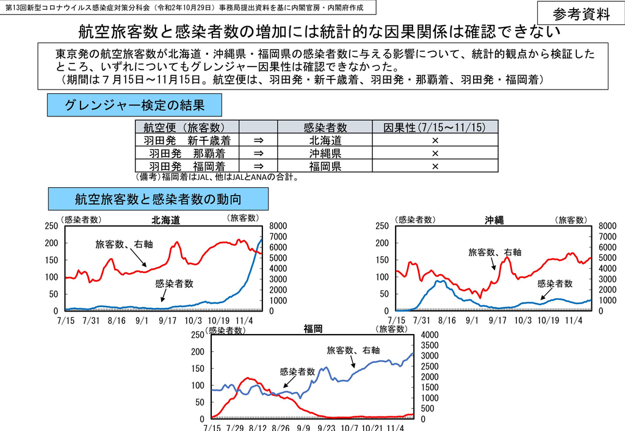

厚生労働省感染症アドバイザリーボード2020年11月19日(木)資料3(参考資料)

「統計的な因果関係は確認できない」→ 「グレンジャー因果関係は」

上昇局面が関係を検出しやすい: 旅客数が先行、感染者数が追従

沖縄(青線)と福岡 (赤線): 推計するには感染ピーク前のデータが短かすぎる、もっと遡ってデータを使うべき

下降局面は検出しにくい: 旅客数が減っても、モメンタム(市中感染による自然増)が減るとは限らない

グレンジャー因果性Granger causality: $A$ Granger-causes $B$

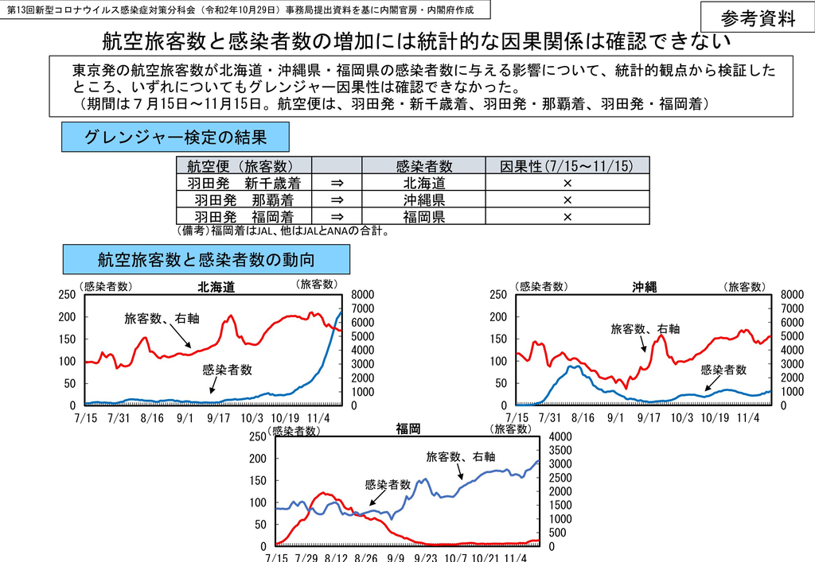

厚生労働省感染症アドバイザリーボード2020年11月19日(木)資料3(参考資料)

ラグ数: どこまで過去に遡るか? 最低2週間、3-4週間くらい?

北海道: 10月1日以降の旅客数の増加によって1ヶ月後に感染者数が増えているようにも見える。推計でどこまで前を考慮しているか不明。

なぜこの3道県だけ?

東京のGoToトラベルは秋以降なので、北海道や沖縄よりも、近隣の紅葉のきれいなところや温泉地に行く人が多そう…静岡、山梨、栃木、福島とかを検討すればいいのでは?

沖縄と福岡: 推計するには感染ピーク前のデータが短かすぎる、もっと遡ってデータを使うべき

東京追加による東京圏(例: 静岡県)の新規感染者数の変化

**被説明変数**

各都道府県の新規感染者数

**データ**

厚労省の日次データ 効果

東京追加前後での: 静岡の変化-合成静岡(=非東京圏加重平均値)の変化

**推計量**

合成統御法(synthetic control method): 非東京圏のデータで「政策なしの静岡」の値を合成し、実際の静岡の値と合成値との差を政策の効果と見なす

被説明変数と相関のある変数で、静岡の値と他の非東京圏道府県の加重平均値の差(の2乗和)を最小化するように加重平均ウェイトを選ぶ。このウェイトと非東京圏の被説明変数データを使って合成静岡の被説明変数値を計算する。

東京追加による東京圏(例: 静岡県)の新規感染者数の変化

**長所**

感染者数をそのものを取り上げている。データは長期のリードタイムがあってこの推計方法に向いている。

**短所**

トレンドが同じになる疫学的根拠なしには、信頼性が高いとはいえない。$\rightarrow$ 独自トレンドの県をドナー・プールから除外すればいい。

**識別仮定identification assumption**

「GoToトラベルによって東京との旅客移動の影響が無視し得る非東京圏(道府県)が複数あり、GoToトラベル東京追加なしの場合に、感染者数トレンドは静岡とこれら非東京圏で等しい」

課題

- 非東京圏が存在するか。
- 非東京圏の道府県を決めるのに一定の恣意性があり、変えると結果が変わる可能性あり。
- 加重平均ウェイトを選ぶときに観察可能な違い(観察可能な変数)のみを考慮している。
  - Selection on the observable

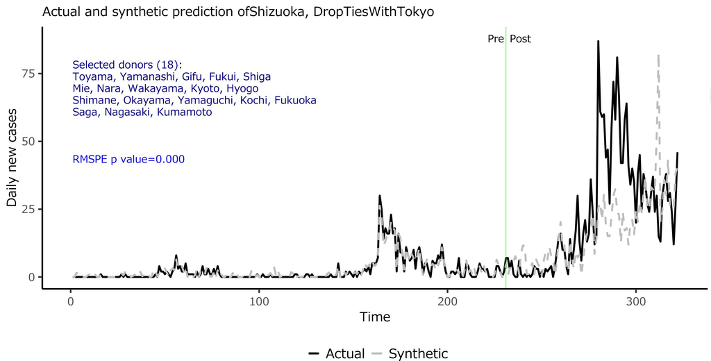

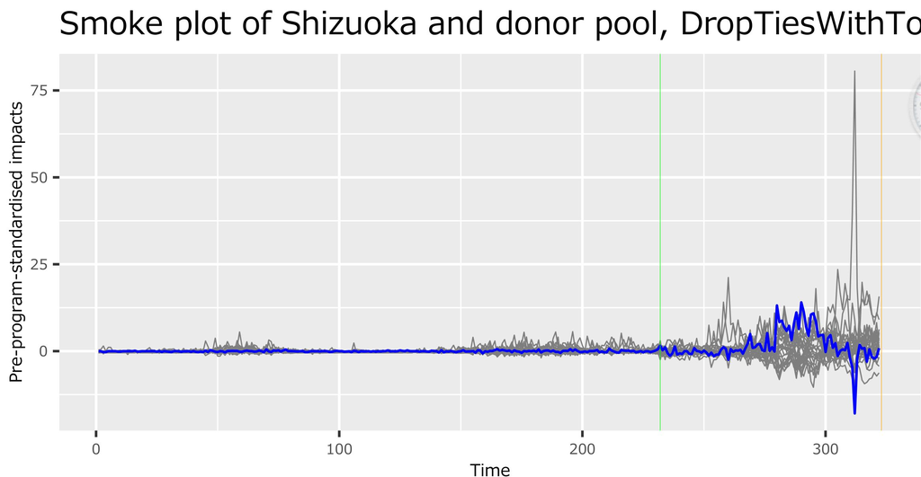

GTT+東京による静岡県の新規感染者数変化

非東京圏: 東京からの宿泊者数が全国平均よりも少ない道府県

スモーク図smoke plot

静岡と東京以外すべての道府県でインパクト推計し、灰色の線で示した

GTT+東京に曝露されたと仮定: 他道府県のインパクト推計値と静岡県のインパクト推計値の比較。静岡の外れ度を示す。

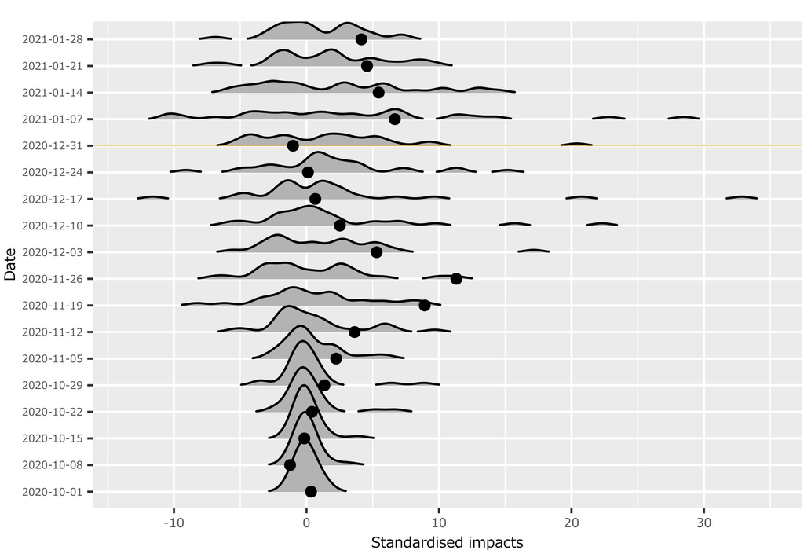

リッジ密度図

スモーク図と同じ情報を別の視覚化

点が静岡、分布がその他道府県のインパクト推計値

静岡インパクト推計値の外れ度を示す

11月後半-12月初旬の3週間で他道府県に比べてインパクトが大きい

実は、CFがなくてもインパクト評価を可能にする方法があるBut there is an ingenious way that allows impact evaluation

用いる仮定: **観察可能な変数による選抜selection on the observable**

観察可能な変数で統御群と治療群への選抜が説明可能 =観察可能な特徴を考慮すれば、統御群と治療群への割り振りがランダム(選抜がない)と考えられるAfter adjusting for observable differencs, the treatment assignment can be considered as good as random

ここで「ランダム」とは?what do we mean by “random”?

観察可能な特徴を考慮すれば、効果の大きさと治療状態が相関していないことAfter considering the observable differences, the impact size and treatment assignment are not correlated

=効果の大きい/小さい人ほど治療群になりやすい、がないことIndividuals/Units with lage/small impacts are more likely to be the treated, does not happen

観察可能な特徴を考慮すれば、治療状態と結果が無相関/統計的に独立を**条件付直交conditional orthogonality/条件付独立conditional independence**という

selection on the observableは滅多に満たされないis rarely satisfied in reality

人間は自分にとって得なことを選択する(=選抜がある)し、選抜に関わる観察不可能な情報が必ずあるhumans choose what they benefit from (=there is selection), and there is always information that explains selection that is unobservable

では、なぜこんな仮定をおいてインパクト評価をするのか?then, why do we estimate impacts by invoking such an assumption?

何もやらないよりも、仮定と限界を明示して作業する方が意義があるためit is worthwhile to estimate impacts while explicitly stating assumptions and limitations, than doing nothing

手法開発者の意図intentions of SCM developer

- 叙述研究はCFを意識しないので信頼性が低い。数量研究はCFについて一定の仮定を満たさないと作業しない。Descriptive/qualitative research often does not consider CF, therefore, has low credibility. Quantitative research does not get carried out unless certain assumptions about CF are met.
- 中間がない。叙述研究と数量研究の橋渡しをしたい。No middle ground. Want to bridge descriptive/qualitative and quantitative research.
- 仮定を明示して、何が言えるかを示すことにも意義がある。Stating assumptions explicitly and show what can be drawn has some values.

オリジナルの開発者の崇高な意志に反して仮定もよく考えずにインパクト評価をやってしまう例は多いが…Nonethless, there are many impact evaluations without thinking about the assumptions deeply, and do not take into account the noble intention of SCM developer…

Abadie and Gardeazabal (2003): テロがバスク郡の経済成長に与える影響を推計。スペインでテロはバスク郡以外にはない。They want to estimate the terrorism impacts on growth of Basque county. Terrorism affected only Basque but nowhere else in Spain.

アイディア: それ以外の郡すべて(“donor pool”)からCFを合成They proposed to synthesise a control observation out of all other counties (“donor pool”).

$$ATT_{basque,t}=\underbrace{y_{basque, t}}_{\scriptsize{\mbox{バスク}}}-\underbrace{\sum_{j=1}^{J}w_{j}y_{j,t}}_{\scriptsize{\mbox{バスク以外の加重平均}}}, \quad 0\leqslant w_{j} \leqslant 1, \ \sum_{j=1}^{J}w_{j}=1.$$

テロ開始前データを使って、テロ無しバスクと加重平均の誤差の2乗和が最小化するようにウェイト$w_{j}$を選ぶ

- なぜ和ではなく2乗和? 2乗和が最小化 ⇒ (その正の平方根の)和が最小化
- 2乗和にするのは数学上の都合: 2乗するとウェイトの関数(=誤差)を最小化(微分)して解を求められるから

[figure not shown]

$w_{j}$の計算方法 (テロ前T期、テロ発生以降$T+1, T+2, \dots$)Computing $w_{j}$

1. 計$J$郡$(j=1,\dots,J)$について結果変数(成長)に影響する$I$個の共変数predictors $x_{1jt}, \cdot, x_{Ijt}$をテロ前の時期$t=1, \dots ,T$について集める。結果変数を全期間$t=1, \dots , T$$, T+1, T+2, \dots, T+L$について集める。Pick variables correlated with growth (=growth predictors) in Basque. Form a vector $\bfx_{Bt}$ for all pre-terrorism periods $t=1,\cdots, T$. Do the same for other $J$ counties and form a matrix $\bfX_{t}=\left(\begin{array}{ccc} \bfx_{1t} & \cdots & \bfx_{Jt}\end{array}\right)$.
2. テロ前$T$期間データ(結果変数と共変数)を使い、バスクとバスク以外の加重平均の差の2乗和を最小化する各変数(結果変数と共変数)$z_{ibt}$共通の郡ウェイト$w^{*}_{1}, \dots, w^{*}_{J}$を選ぶ。Minimise normalised sum of square differences $\sum_{t=1}^{T}(\bfx_{Bt}-\bfX_{t}\bfw)'\bfV^{-1}(\bfx_{Bt}-\bfX_{t}\bfw)$ by choosing weighting vector $\bfw$ optimally. Denote the optimal weight as $\bfw^{*}$.

事前$I$個×$J$主体×$T$期間, 事後$1$個×$J$主体×$L$期間

- バスクの$t$期の$i$変数$x_{iBt}$の誤差$e_{it}=x_{iBt}-\sum\limits_{j=1}^{J}w_{j}x_{ijt}$
  - バスクの$t$期の$i$変数$x_{iBt}$-その他地域$j(=1,\dots, J)$の$t$期の$i$変数$x_{iBt}$の加重平均値weighted mean
  - $w_{j}$は$j$地域の加重weight, $w_{j}\in[0, 1]$、$\sum\limits_{j=1}^{J}w_{j}=1$
- バスクの$i$変数$x_{iB}$の誤差2乗和$sse_{i}=\sum\limits_{t=1}^{T}e^{2}_{it}$
- バスクの$I$個の変数ベクトル$x_{1Bt}, \dots, x_{IBt}$の誤差2乗和$sse=\sum\limits_{i=1}^{I}\frac{sse_{i}}{I}$

誤差2乗和$sse$を最小化するように$J$個の$w_{j}$を選ぶ←数学の最小化問題、簡単です

- $I=1$は結果変数(=感染者数)のみを使うとき
- $I=1$でも良いが、たいていは複数の変数(共変数covariates)を使って$w_{j}$を計算
  - 共変数: 人口密度、投資率、各産業シェア、識字率その他学歴人口比率←GDPに影響する変数
- 2乗和関数$\sum\limits_{i=1}^{I}\sum\limits_{t=1}^{T}\left(x_{iBt}-\sum\limits_{j=1}^{J}w_{j}x_{ijt}\right)^{2}=\sum\limits_{i=1}^{I}\sum\limits_{t=1}^{T}e^{2}_{it}$に最小化の一階条件を使う
- $\sum\limits_{j=1}^{J}\hat{w}_{j}y_{jT+1}=\hat{y}_{T+1}, \sum\limits_{j=1}^{J}\hat{w}_{j}y_{jT+2}=\hat{y}_{T+2}, \cdots$がテロ以降のテロ無し合成バスク。

結果変数と共変数という観察可能な変数を使ってCFを作っている

- 観察可能な変数が似ていればcontrol → 観察可能な変数が似ていればtreated/controlの割り当てはランダムと想定

観察可能な変数$\bfx_{i}$で自己選抜が説明可能: **selection on the observable** $y_{i}\perp D_{i}|\bfx_{i}$

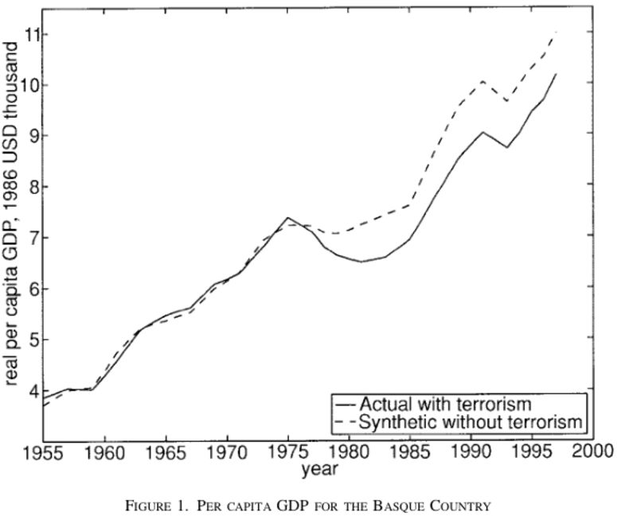

Terrorism impacts on growth: T=1969

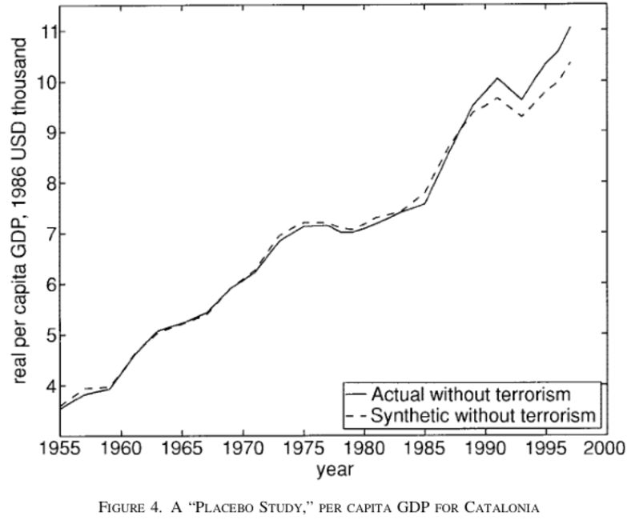

A placebo study: Catalonia: バスクに似ているがテロがない

SCMが適しているデータSCM can be applied to the study with a small number of cross sectional units but with a relatively long (e.g., 10-30 periods) pre-policy observation period (“training period”)

- 治療群が少なく統御群(ドナー・プール)が多いSmall number of the treated, large number of the control
- 「推計標本estimation sample」(=イベント発生前)の期間$T$が比較的長い(10-30期間など)Estimation sample (pre-period or training period) is relatively long (10-30)

推計期間での予測誤差が大きいとイベント後の予測も精度が低いので、使えないIf the fit of (within sample) prediction during training period is bad, there is nothing you can do.

短所 :どの程度の誤差なら良いのか現在は基準がない、共変数選定の基準がない、イベント前データが長期に必要 No formal criteria about the minimum degree of training period fit, no guidance on covariate selection

長所 :比較対象の選択基準を客観化、プラセボ検定が可能Objective criteria of comparison group selection, can do placebo tests

観察可能な変数による選抜の意味what we mean by selection on the observable

治療群と統御群は観察可能な変数のみを基準に選抜されたthe treated and the control are assigned through the use only of the observable characteristics/variables

テロリストが(カタルーニャやマドリよりも)バスクを選んだのは成長率が下がって不満を持った市民や支持を得られそうと思った(=観察不可能な思い込み)、からではない」

「成長を低めテロを育てるような要因(例: 分離独立運動)はない」

「共変数$\bfx$を考慮すれば、テロがなければ成長はほぼ同じだった」

「テロが起こるとすればバスクしかなかったが、共変数$\bfx$を考慮すれば、テロの原因と成長とは関係がない」

SCMの考え方: 共変数が似ていれば結果も似ているはず Idea of SCM: If the covariates are similar, so are the outcomes

暗に仮定している共変数と結果の関係This assumes that the relationship (supposedly derived from a theoretical model but never explicitly shown) between predictors and outcomes are:

1. 横断面に均質cross-sectionally uniform
2. 安定的(=時系列に均質)stable (uniform in time)

強い仮定に思えるが、これらは叙述的研究も同じBut these may be the same for qualitative, narrative studies.

叙述的研究と比べた長所

1. 比較対象を選ぶ基準がある程度客観的
   - ただし、共変数を変えるとウェイトも変わるのである程度操作可能
   - よって、理論に照らし合わせて共変数を選ばねば(=共変数選択を理論によって制約しなければ)ならない=理論に即した選択で推計結果の信頼性を高められる
2. 効果(=比較対象との差)を数値化して、その値がゼロに等しいか仮説検定が可能

Abadie, Diamond, and Hainmueller (2010) :

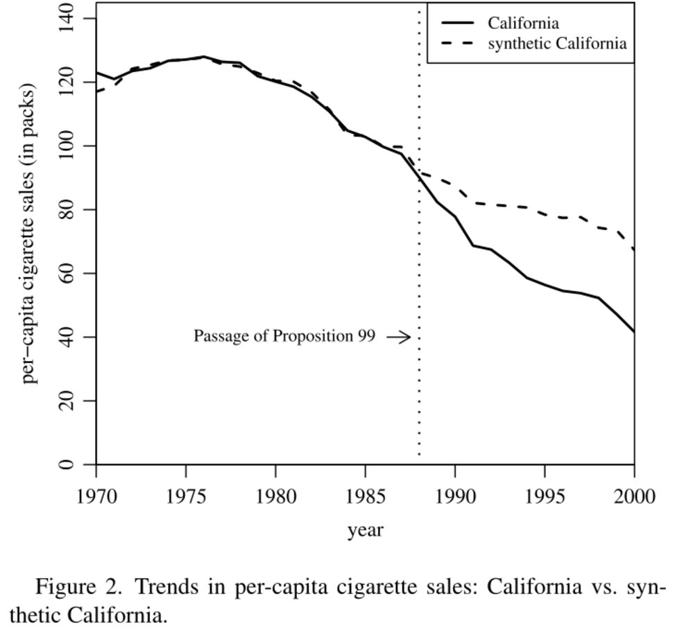

Tobacco tax in California and per capita cigarette sales

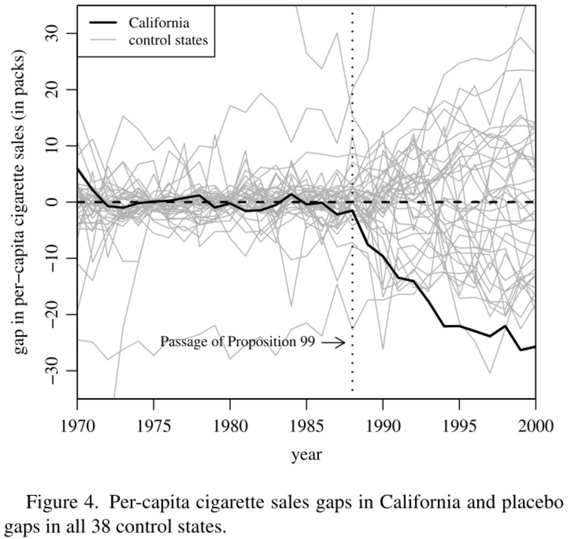

Tobacco tax in California, placebo studies on all control states, lines show gap = actual - synthetic contro

Pinotti (2015) on effects of mafia violence on growth

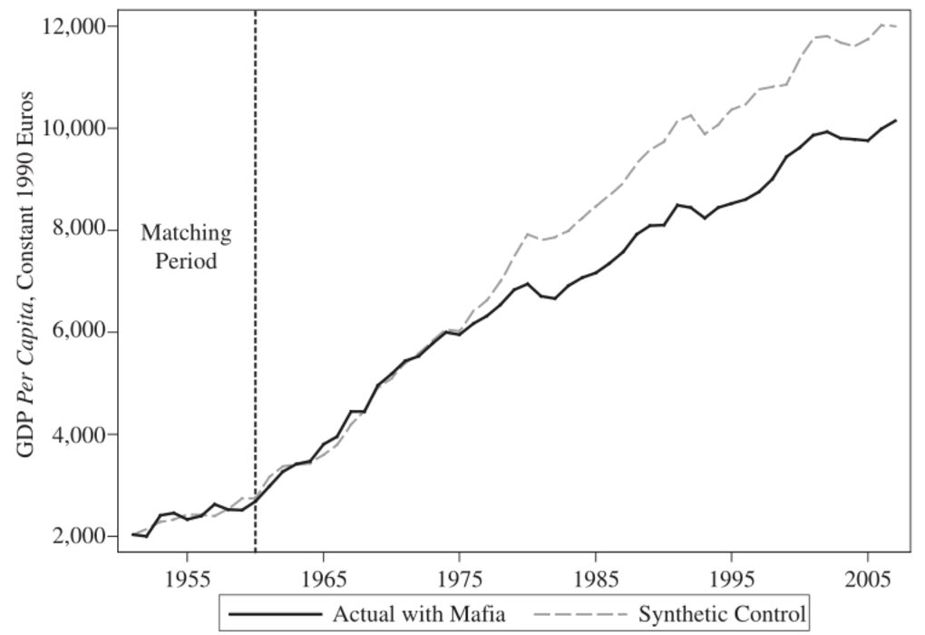

Mafia violence on growth in Apulia and Basilicata

Pinotti (2015) on effects of mafia violence on growth

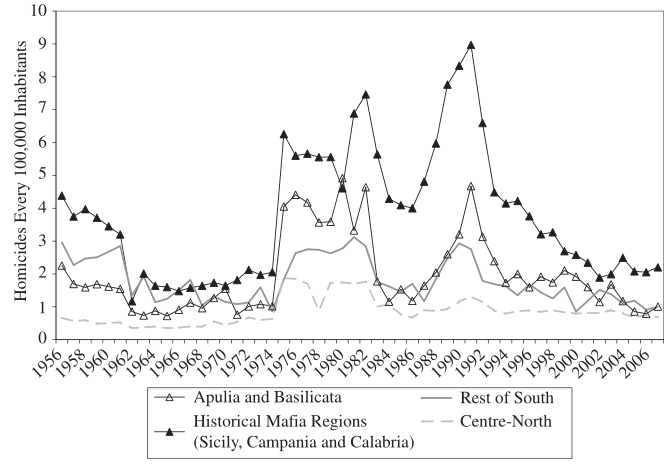

Apulia and Basilicata were new to violence

Pinotti (2015) on effects of mafia violence on growth

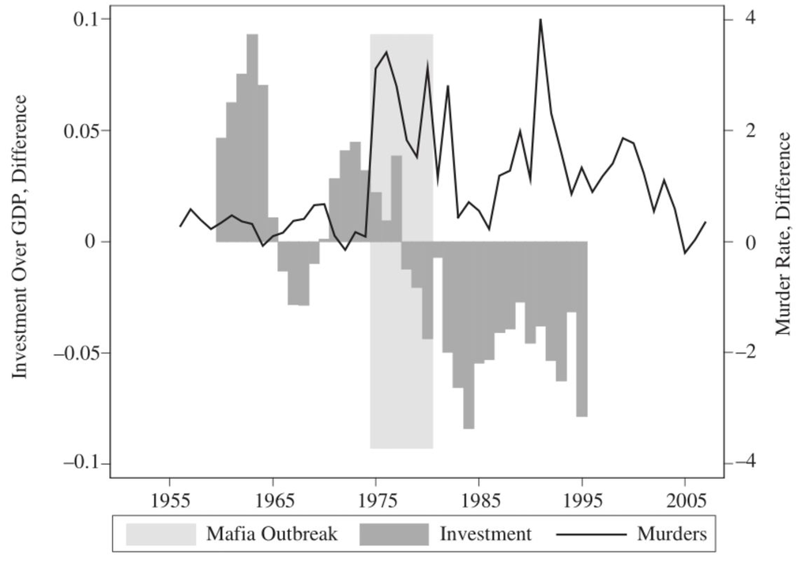

Mafia violence deters investments

Pinotti (2015) on effects of mafia violence on growth

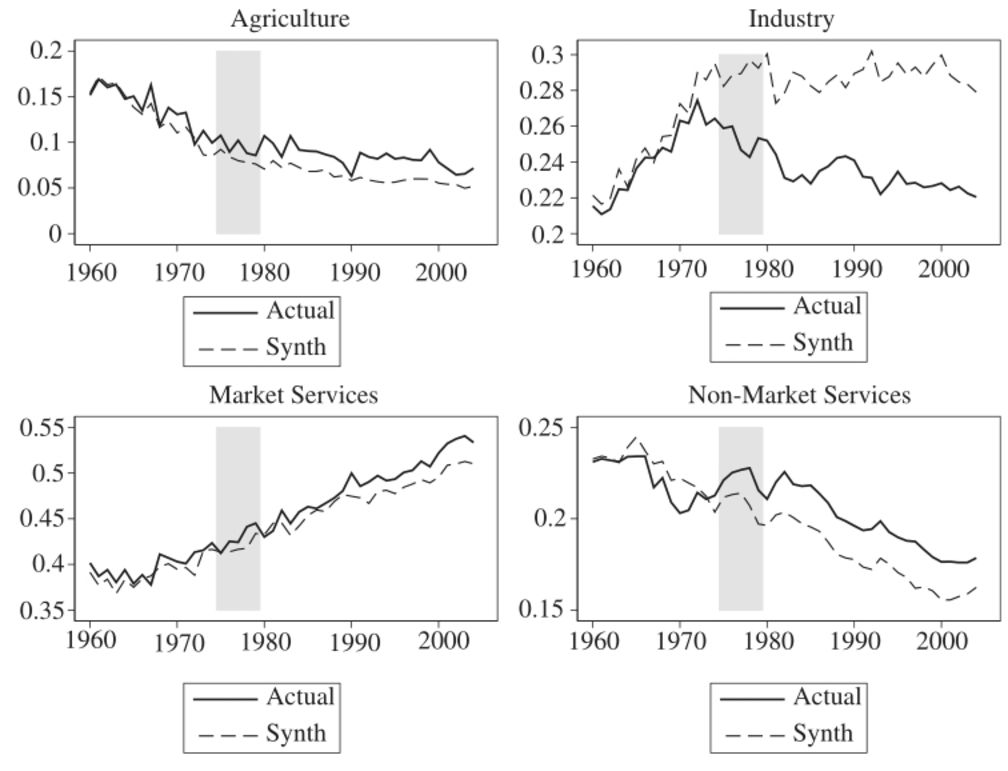

Mafia violence slows industry (% of provincial GDP)

Pinotti (2015) on effects of mafia violence on growth

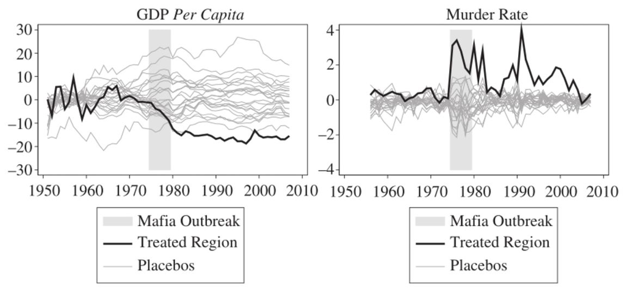

Mafia violence placebo studies

It is still possible that something other than mafia violence caused the slowdown of industrial growth of Apulia and Basilicata, starting from early 1970’s. But what is it? If none is found, SCM (may not be very credible but) is convincing.

Pinotti (2015) also shows that;

- Private investment dried up↓
- Public investment increased↑
- Private employment reduced↓
- Public employment increased↑ but did not offset the reduction in private employment↓

He argues that increased public investments were channeled to mafia activities through corrupt politicians, and quality of elected politicians reduced (shown in the companion paper).

Pinotti (2015)

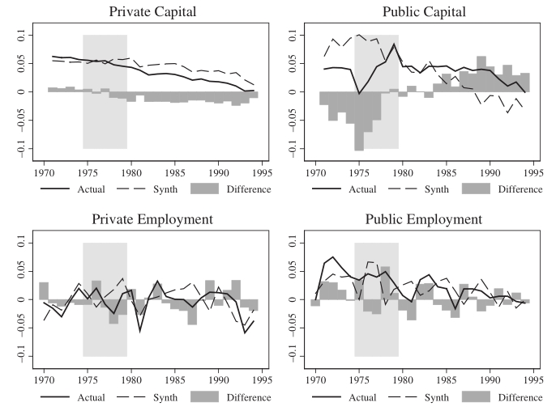

Private and public investment and employment

Billmeier and Nannicini (2013) on the effects of trade liberalisation on growth

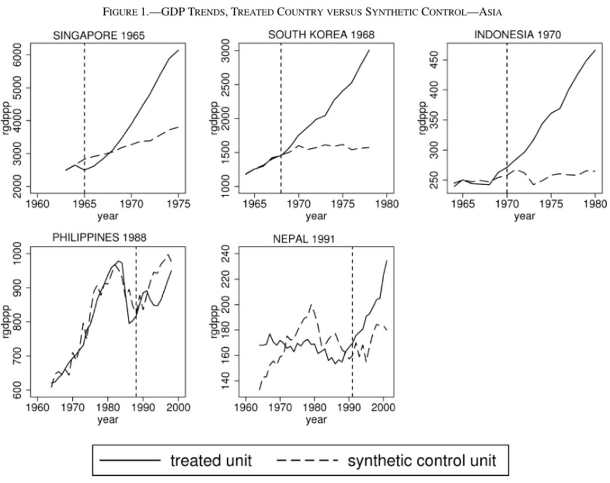

貿易自由化の効果、Asia

Billmeier and Nannicini (2013) on the effects of trade liberalisation on growth

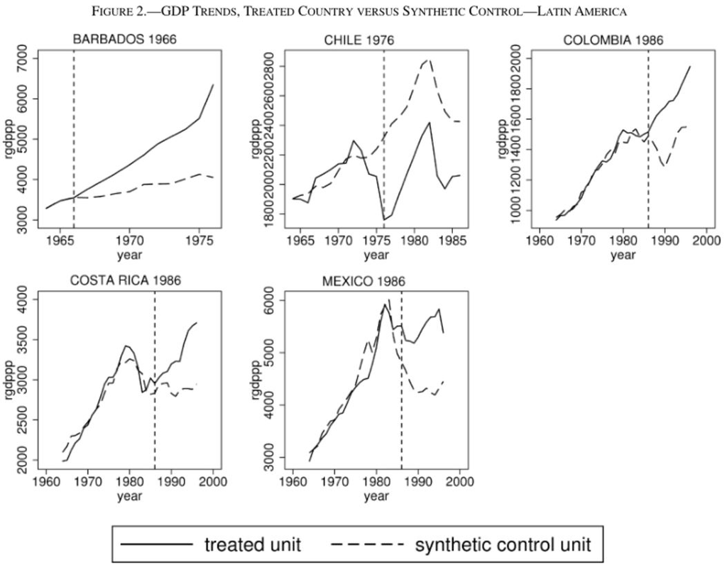

Latin America

Billmeier and Nannicini (2013) on the effects of trade liberalisation on growth

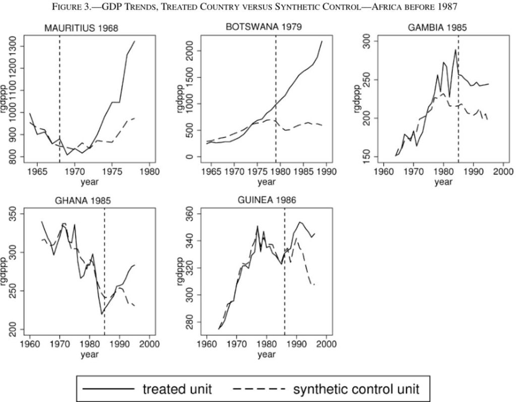

Africa before 1987

Billmeier and Nannicini (2013) on the effects of trade liberalisation on growth

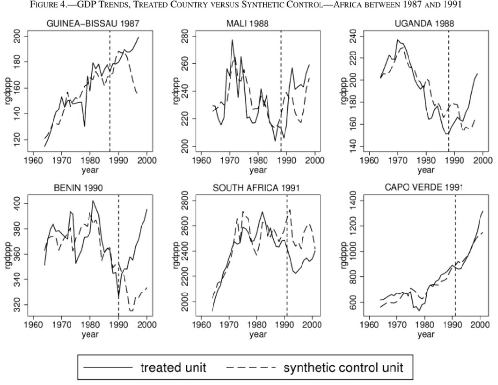

Africa 1987-91

Billmeier and Nannicini (2013) on the effects of trade liberalisation on growth

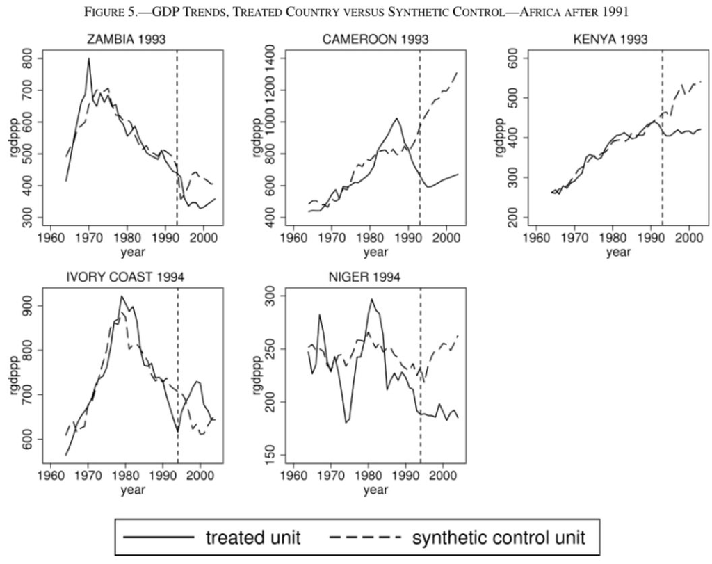

Africa after 1991

Billmeier and Nannicini (2013) on the effects of trade liberalisation on growth

怪しい結果に思えるquestionable results

- 貿易自由化していないdonor poolを使って加重平均を合成uses a donor pool that has not gone through trade liberalisation to construct a weighted mean
- 共変数: 中等就学率、人口増加率、投資/GDP、インフレ率、民主主義インデックスcovariates: secondary school enrollment rates, population groth rates, investmet rates, inflation rates, democracy index
- 共変数が似ていて(貿易自由化していなくて)も、成長率は人口規模、天然資源、気候変動、紛争などによっても影響されるeven when covariates are similar, growth can be affected by population size, natural resource endowment, climate change, conflicts

どこまで共変数として含めれば良いのか、誰も説得的な議論はできないno convincing argument has been made for what variables should be used as covariates

しかし、叙述的研究はそういうことをやっているbut descriptive research does these things, too

- 選定基準を明確化して数値化しているだけましbetter if we make selection criteria explicit and numerical

# Various attitudes toward

IMPACT EVALUATION

It is fair to say that *ex post* evaluation uses a poor method in estimating impacts which should not be taken too seriously.

http://www.jica.go.jp/english/our_work/evaluation/tech_and_grant/project/ex_post/about.html

> We believe the policy had an impact, however, it is difficult to know. (honest!)

> Based on the responses from beneficiaries, it is confirmed … was improved. (subjective)

> …one can judge that the effect was an increase in income. (unsubstantiated)

> …it is perceivable that the policy provided a support for growth. (unsubstantiated)

> … it is considered that the effects on job creation was sufficient. (subjective)

We cannot learn which policy was effective.

CGD document: *When will we ever learn?* (Evaluation Gap Working Group 2006)

Asking, do we know how to improve outcomes of the poor? After more than 50 years of aid business?

Donor agencies’ evaluation professionals did not have a good answer.

We need to produce knowledge from past policies to inform future policies.

**Millenium Villages (2004-2015)**

RCTではないこと、統御群データがないことなどから、実施したインパクト評価(before-after)の信頼性credibilityは低く、成果がよく分からないまま終わった

壮大な実験であり得たのに、評価の準備をしていなかった

なぜ?

Buse, Ludi, and Vigneri (2008) : Before-after比較

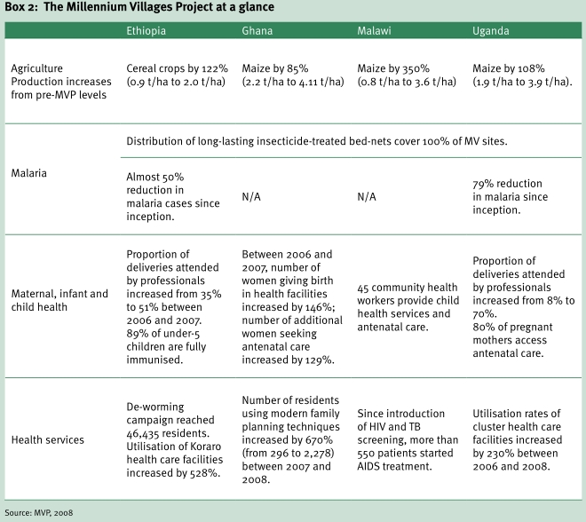

- 穀物反収↑
- マラリア報告件数↓
- 母子保健利用↑
- 医療サービス利用↑

Clemens and Demombynes (2011), DID vs. before-after

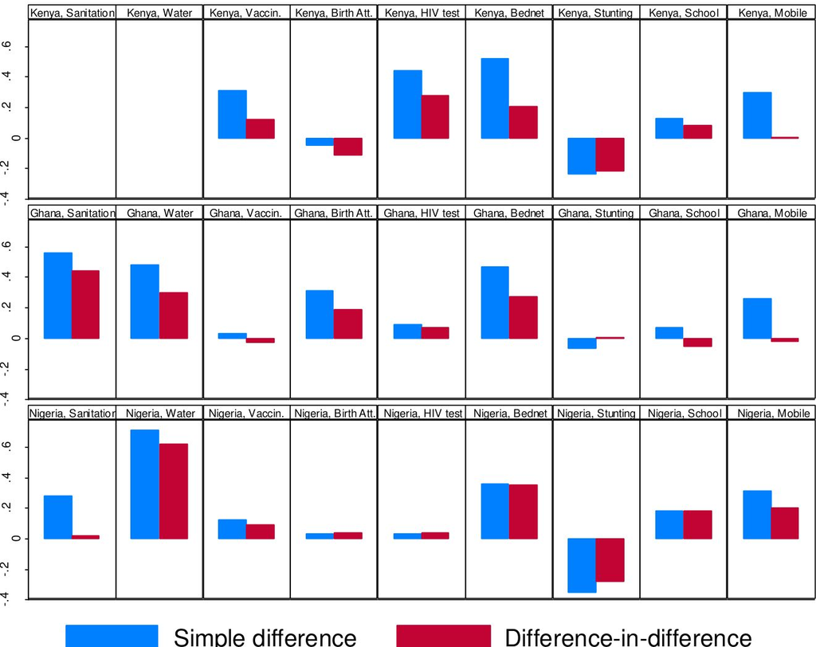

Clemens and Demombynes (2011), Figure 10

- B-A比較が意外にDIDと類似…
  - B-A比較が良いのか?
  - それとも、DIDもダメなのか?
  - Pre-trend検定がないので分からない…こういう評価デザインのプロジェクトなので、pre-periodのデータが1期間しかないかも
- B-AはDIDよりも効果推計値が上振れ

なぜ信頼性の高いインパクト評価が可能な準備をしなかったのか?

A short answer: インパクト評価に関する勘違い(もしくはその振りをした)

Sachsらによる説明とDavid MacKenzie (世銀)による反論 (https://blogs.worldbank.org/impactevaluations/jeff-sachs-the-millennium-villages-project-and-misconceptions-about-impact-evaluation)

1. 村は常に変化しているから、村レヴェルでの実験に統御群は作れないWith communities, there are no true controls. Life changes everywhere, in the MVs and outside of them.
   - 村が常に変化しているからこそ、実際の村が統御群として必要
2. 介入は村が自ら学んで改善するという過程を経る。この過程はRCTで評価できない。The logic of simple randomized trials does not apply in a context of design with extensive learning by doing, where the main goal is to develop new tools and systems that are replicable and scalable and used by the community itself
   - (率直に何を言っているのか理解できないほど)勘違いしている
   - 学んで改善を記録するとはプロセス評価process evaluationのことで、必要性を誰も否定していない
   - 学んで改善してもインパクトはまだ分からないから、インパクト評価は必要
   - プロセス評価とインパクト評価を混同
3. 初年度は忙しくて統御地域を設定できなかった。既存の全国データがあるのに、少数の統御地域だけと比べる意味はあるのか。統御地域とペアにして比較しても、統御地域が経済的に変わったら比較する意味はあるのか。

There has been much naïve talk about paired “comparison” villages…(snip)… in year 1 the considerable work required to create a foundation of community-driven strategies in the context of a very complex project took precedent…(snip)…Spending a great deal of time and personnel on one particular “comparison site” is misplaced concreteness. ..(snip)…The comparison village is definitely not a “control” village in the sense of a real, unchanged control, nor could it be…No place is standing still to be a control site … If the comparison site happens to get a new road or an extension of the power grid, this gives an artificial “small sample” error to the comparison with the MV.

- 最初に候補を作って治療群と統御群に割り振れば良いだけ(忙しいのは事実だけど)
- 既存の全国データには含まれないような情報を治療群では集めているので既存データでは不十分
- 変わるからこそ統御群が必要
  - 確かに、統御群が別ショックの影響を受けるかも
  - だから、そうした影響を受けそうにない近似した統御群を選ぶべき
  - 統御群を用意しない理由にはならない

真の理由?

- 倫理的ではない、政治的に難しいから統御群を作らない、と2007年時点で Sanchez et al. (2007, 16779)が書いていた

> For ethical and practical reasons, there are no formal ‘‘control’’ villages. Instead, project impact is assessed by rigorous before-andafter comparisons and detailed studies by sector. … (snip) … The ethical reasons relate to the fact that many core interventions (e.g., malaria control, access to safe water) are life-saving and would be ethically inappropriate to deny in a control village. The project also discovered that in some of the sites it was not politically feasible to be deeply involved in monitoring a control village without also offering a substantial package of beneficial interventions.
- しかし、2008年には比較村が誕生、Mitchell et al. (2018) は観察可能な変数の特徴が近似している5比較村/国との比較で効果推計
  - どれだけ各変数が治療群村とマッチしているかで比較対象を選ぶmatching estimator
  - マッチ対象候補村データはMVP開始以前に収集された2次データ(Demographic and Health Surveyなど)
  - さらに、endlineで調査をして変数を収集
- matching estimator: 識別仮定=selection on the observable
  1. 各治療村ごとに各変数の値が最も近い村をペアにする方法(covariate matching)
  2. 各治療村の治療確率と近似するように比較村を選ぶ方法(propensity score matching)
- 効果=endlineでの治療群平均値-比較群平均値
- 批判に応えてこの評価デザインにした
- 事後的にどのような対応ができるかの好例、予算は相当ある場合

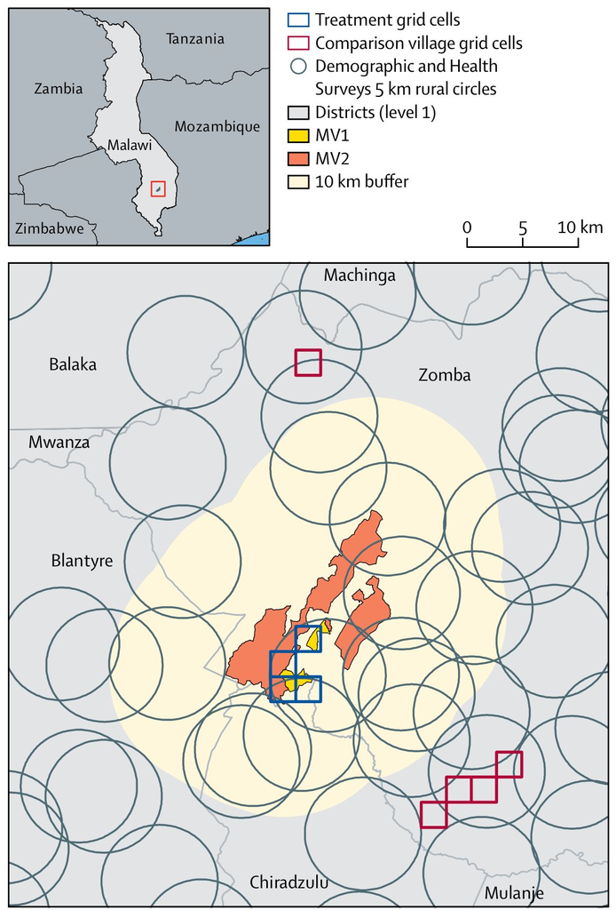

Mitchell et al. (2018), Figure 2

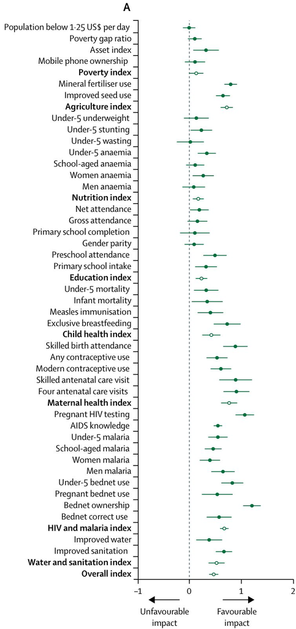

Mitchell et al. (2018), Figure 3A

- All indices show positive impacts
- 最初から統御群を作っておけば良かったのに

# Rethink what estimated results tell us

治療群と統御群が似ていても、研究デザインの信頼性が低い場合や対象母集団が特殊である場合は、得られた知識が歪んでいる場合があります

1. Multiple testing ($p$ hacking)
2. Small sample bias
3. Publication bias

全ての推計方法への批判1: multiple testing ($p$ hacking)

- $p$値=「帰無仮説(効果ゼロ)が正しい確率」。効果の平均値がゼロの母集団から$n$回標本を集めて検定すると、推計結果よりも極端な結果は$p$の確率(=$np$回)しか発生しない、ということ。$p$ value: Roughly, probability of the null hypothesis (of zero impact) being true. From the population of mean zero impacts, draw $n$ impact values, then you will get results more extreme than you currently have at $p$ percent probability ($np$ times).
- $p$が小さいほど「外れ値」なので効果ゼロを疑問視して良いThe smaller the $p$, the more extreme the current estimate, hence the more you can question the zero impact
- $p=5\%$ $\Rightarrow$ 効果の平均値がゼロのとき、$n=100$回に$np$=5回は発生するかも、という「外れ」度If your threshold of extremeness is 5%, when the true mean impact is zero, you will have “extreme” (“statistically significant”) impacts for $np=$5 times when you sample $n=100$ times

全ての推計方法への批判1: multiple testing ($p$ hacking)

- 少しずつ異なる推計式定式化を100回試すと、真の効果がゼロでも5回くらい推計値が外れ値になるIf you estimate different but not too different (so the population is same for all) specifications 100 times, even when the true impact is zero, your estimate will be extreme for 5 times
- 外れ値を得るまで何度も推計式定式化を変えると、望む結果が(理論的には)必ず得られるIf you try different specifications as many times as necessary, you will get an estimate that you look for
  - 対策: Pre-analysis planを公開する、最低でも研究再現性のために推計のコードと結果を公開するpublish pre-analysis plan, or, at least, estimation code and outputs for reproducibility
    - コードを公開して誰もが追試できれば、なぜこんな変数を右辺に使っているのか、なぜこんな定義にしているのか、のような細かな推計式定式化の選択について疑問点が自然と出てきて、外れ値を得るために何度も試行したかが分かりますif you publish your estimation code, questions like, why does the author use this variable on RHS, why using such a definition, etc. will spawn out which may reveal if the author tried many specifications to get desired results

全ての推計方法への批判1: multiple testing ($p$ hacking)

- 似た結果指標(例: 疲労と労働時間)への効果推計←multiple testingを無意識にやっているsimilar outcome indicators (e.g., fatigue and work hours)←unintentional multiple testing
  - 対策: 同じ結果指標グループの$p$値平均値family wise error rateを使う、同じ結果指標グループを指数化するCountermeasures: use the mean of $p$ values of similar outcomes (called “family wise error rate”), create a single index of similar outcomes using the normalised estimates and their standard errors
    - family wise error rateなどは似た推計値が幾つあっても$p$ hackingできない
    - 指数化=効果を(結果指標の標準偏差で割ることで)標準偏差単位にして(標準化standardisationという)、結果指標1を(結果指標1の)標準偏差単位でx1単位高める、結果指標2を(結果指標2の)標準偏差単位でx2単位高める、と足し算できるようにし、標準化された効果の平均値とその標準誤差を計算し、$p$ valueを得る
- You do not end up p-hacking even if you have many impact estimates so long as you use family wise error rate
- You divide the impacts with standard deviation of the outcome measure to get impacts in terms of standard deviation units (this is called standardisation). Then you average all the standardised impacts of all the impact estimates (of the same family) and compute its standard errors (formula of “standard error of the mean” is simple) to get $p$ values.

全ての推計方法への批判2: small sample bias

- Gertler et al. (2014), Jamaica: 早期児童発達介入で成人時所得が25%増加(報告当初は42%だったが訂正), 治療群+統御群=109人
- Heckman et al. (2010), Perry preschool: 内部収益率7-10% (研究当初は15-17%だったが訂正), 治療群+統御群=123
- Campbell et al. (2014), Abecederian: 成人時血圧など改善、治療群+統御群=111→33(35歳)

先入観・常識: そんなに大きいはずがないprejudice/common sense: cannot be that large https://statmodeling.stat.columbia.edu/2013/11/05/how-much-do-we-trust-this-claim-that-early-childhood-stimulation-raised-earnings-by-42/

小標本=誤差が大きい=分散が大きい=分布の裾野が広いsmall sample=large errors=large variance=wider tails of distribution

全ての推計方法への批判2: small sample bias

- 平均ゼロ、大きな分散の分布で$p$値5%: 推計値(の絶対値)が大きくないと実現しないdistribution of mean zero, large variance: need a large estimate (in absolute value) to have a $p$ value=5%
- $p$ hackingをすればいつかは大きな効果を推計できるif you $p$-hack, you will get a large estimate eventually
- ずるではなく偶然大きな値になった可能性もあるmay be unintentional, may be by chance
  - プロならば、小標本バイアスに警戒すべきif you are a professional, got to be aware of the small sample bias
- placebo testでも$p$ hacking可能(プラシーボの効果がゼロを探索)you can $p$-hack in placebo tests (look for a zero estimate of a placebo impact), too

全ての推計方法への批判2: small sample bias

- 小標本で大きな効果: 効果ゼロの可能性が高いsmall sample, large impact: likely a zero impact
- 小標本の研究は信頼性が低いsmall sample research has low credibility
- よほどのメリットがない限りやらない方が良いif not with very good merits, advised not to carry out
- Heckman curveは本当にあの形か? 水平線かも?Is the Heckman curve really shaped in that way? Can be a horizontal line?

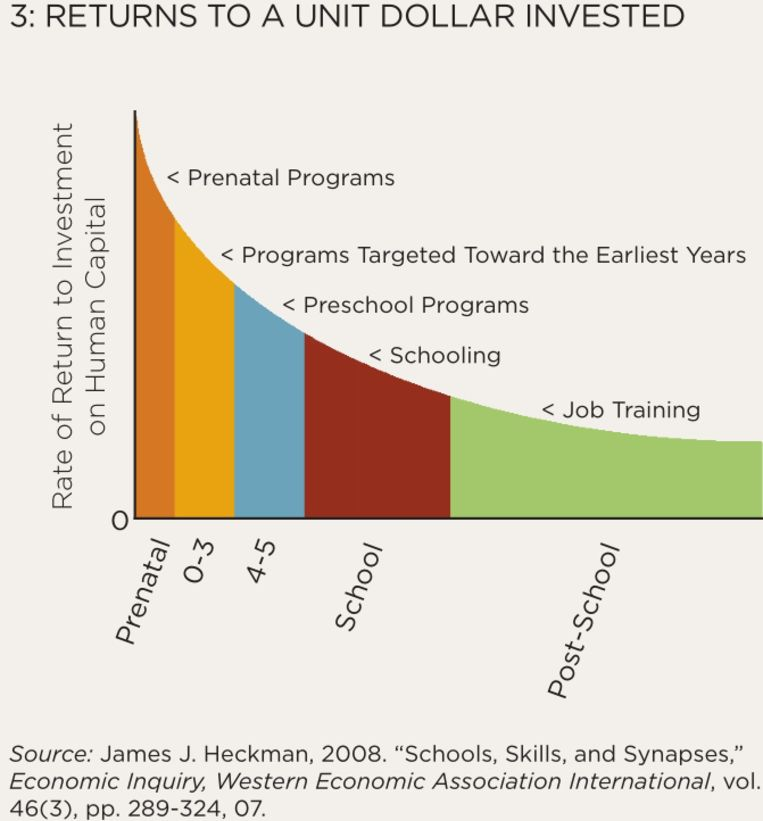

ヘックマンらの研究では認知能力(IQ)と非認知能力(中身=executive function、忍耐力、やる気grit、対人スキル)の両方が所得と関わっており、前者は3-5歳くらいまでに決まるが後者はそれ以降も変化する、としているStudies by Heckman and coauthors indicate that the cognitive ability (IQ) and the noncognitive ability (executive function, perseverence, grit, interpersonal skills) are both related to incomes, and the former is determined by 3-5 years old while the latter changes even after that

全ての推計方法への批判3: Publication bias

アフリカに関する経済学論文27,000本あまり(2000-2019)の地理分布

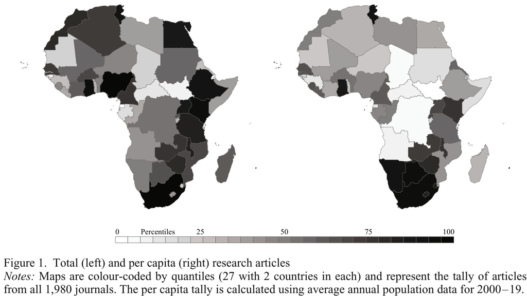

Porteous (2022), Figure 1

[figure not shown]

Source: freepik.com

一国あたり本数の違いの93%が以下で説明可能

- 平和か
- 政治体制
- 海外観光客数
- 公用語に英語
- 人口

アフリカ経済学研究の知識の地理的分布には相当偏りがあります

全ての推計方法への批判3: Publication bias

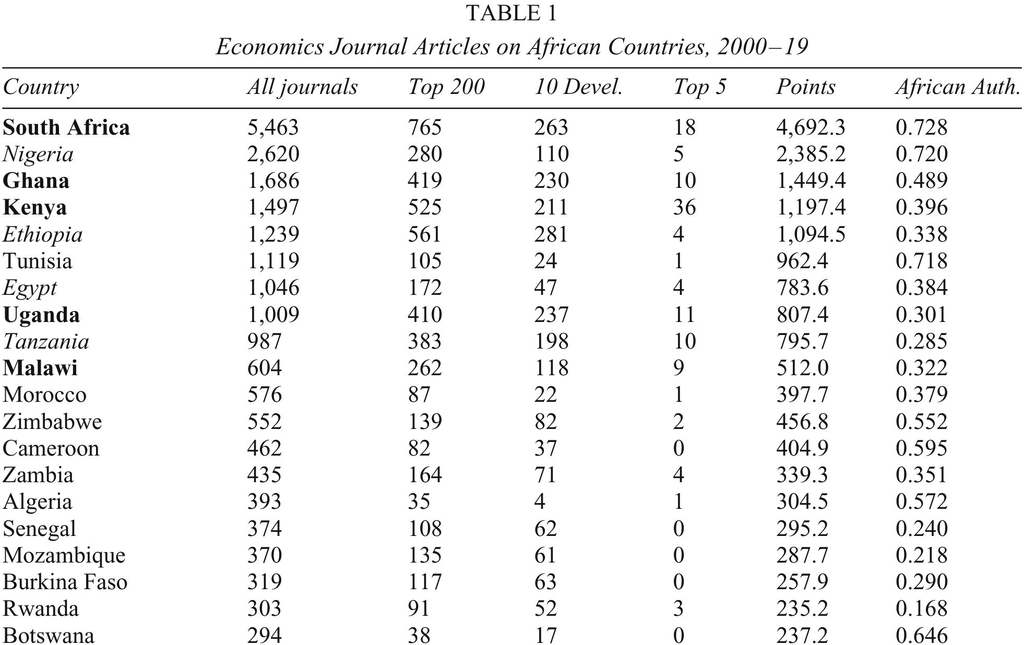

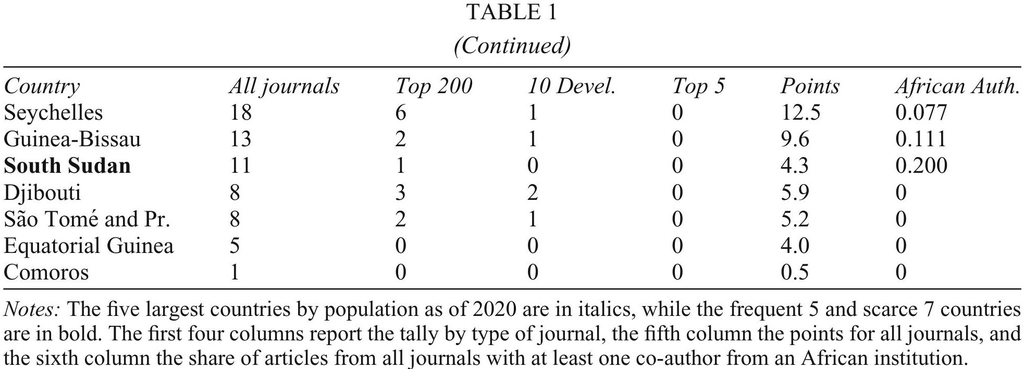

Porteous (2022), Table 1

- 人口が多い英語公用語国がトップ
- 自国で学術雑誌を持っていると上位(e.g., South African Journal of Economics)

アフリカの経済研究で得られた知識=こうした地域からの知識

知識の出自が偏っていることを知るべき

- 西アフリカでも同じ結果?
- アフリカ中央部でも同じ結果?

自国での研究がないと、効果が異なる(かもしれない)のに政策が実施されてしまうかも、という意味で不利

まとめ

効果推計の議論にはレヴェルがある: **初心者、プロ、応用**

相関関係: 3通りの因果関係、見せかけの相関

因果関係: 方向性のある関係

社会科学データで因果関係を直接観察できることは非常に稀

(← 社会経済は相互依存: 原因も何かの結果)

多くの「効果」の議論: 相関関係を因果関係に解釈している可能性

(← 因果関係と解釈した方が進化で生存可能性が高かった(説))

(回帰)式は左右が等しいことを示すだけ、因果の方向は示さない

効果$=$影響を受けたときの結果$-$影響を受けなかったときの結果

CFを作り出す仮定が必要

この仮定が現実的=信頼性の高い効果推計値

多くの「効果」の議論: CF=beforeやwithout、信頼性が低い

← 選抜があるため

因果関係を測定する推計方法

**RCT**

内的整合性あり、対象が限定され高価、仮定=実験が緻密に制御

**Natural experiment**

非倫理的でも実施、実験を探す必要、仮定=ランダム化あり、他要因なし

**DID, event study design**

実験不要、両群のパネル・データが必要、仮定=共通トレンド

**RDD**

実験不要、ローカルな効果、仮定=政策のみ離散的変化

**SCM**

実験不要、大きな観察単位・叙述研究・二国(群)間比較と親和的、長い事前データ必要、仮定=観察可能な選抜

(他にもある…Wald (instrumental variables) estimator that gives LATE、matching estimator)

with-withoutはRCT・NEのみ、before-afterはDIDをすべきなので統御群も必要

placebo test: 効果があり得ない部分で効果計測、効果検知すると推計値を疑問視、しかし、「出ないでほしい」という思いを叶えるような$p$ hacking可能

信頼性の高い推計方法でも、$p$ hacking, small sample biasは存在することに注意

信頼性の高い推計方法、$p$ hacking, small sample biasがなくても、publication biasがあるので、適用範囲や一般化を考える際に注意

仮に信頼性の高い効果推計値を得ても、外的整合性があるかは別問題

全ての推計方法は効果発現メカニズム(理論)を明らかにしない

メカニズムが分からないと他所での適用可能性が分からない

しかし、メカニズムを示唆する検討が可能なこともある

例: マフィア$\Rightarrow$民間の投資・雇用低下、政府の投資・雇用増加$\Rightarrow$成長低下

イタリアで起こったことは日本でも起こるか?

現代日本で暴力団抗争が激化しても、同じメカニズムが働くとは限らない

理由: 警察が強いから。抗争に一般人を巻き込むと警察が弾圧。

「賃金中央値までなら最低賃金引き上げは雇用を減らさない」「余地の大きい日本でも引き上げよう」

アメリカやイギリスでそう(DID)でも、日本でそうかは分からない

ハンガリー: 引き上げの75%が消費者に転嫁、10%雇用減(DID)

理由: 労働市場集中度、産業構成(とくに貿易財比率)、雇用慣行、労働規制が違う

**Millennium Development Villages**

An attempt to mimic a Big Push that intervenes the African villages in every aspect of life.

**J-PAL**

A research centre focusing on randomised controlled trials (RCTs) to produce practical policy lessons.

**internal validity**

An unbiased causal inference.

**external validity**

An unbiased causal inference with applicability beyond studied subjects.

#### References

Abadie, Alberto, Alexis Diamond, and Jens Hainmueller. 2010. “Synthetic Control Methods for Comparative Case Studies: Estimating the Effect of California’s Tobacco Control Program.” *Journal of the American Statistical Association* 105 (490): 493–505. https://doi.org/10.1198/jasa.2009.ap08746.

Abadie, Alberto, and Javier Gardeazabal. 2003. “The Economic Costs of Conflict: A Case Study of the Basque Country.” *American Economic Review* 93 (1): 113–32. http://www.atypon-link.com/AEAP/doi/abs/10.1257/000282803321455188.

Akabayashi, Hideo, and Ryosuke Nakamura. 2014. “Can Small Class Policy Close the Gap? An Empirical Analysis of Class Size Effects in Japan.” *The Japanese Economic Review* 65 (3): 253–81. https://doi.org/https://doi.org/10.1111/jere.12017.

Angrist, Joshua D., and Victor Lavy. 1999. “Using Maimonides’ Rule to Estimate the Effect of Class Size on Scholastic Achievement.” *The Quarterly Journal of Economics* 114 (2): 533–75. http://ideas.repec.org/a/tpr/qjecon/v114y1999i2p533-575.html.

Arkhangelsky, Dmitry, Susan Athey, David A. Hirshberg, Guido W. Imbens, and Stefan Wager. 2021. “Synthetic Difference-in-Differences.” *American Economic Review* 111 (12): 4088–118. https://doi.org/10.1257/aer.20190159.

Barth, Daniel, Nicholas W. Papageorge, and Kevin Thom. 2020. “Genetic Endowments and Wealth Inequality.” *Journal of Political Economy* 128 (4): 1474–1522. https://doi.org/10.1086/705415.

Billmeier, Andreas, and Tommaso Nannicini. 2013. “Assessing Economic Liberalization Episodes: A Synthetic Control Approach.” *Review of Economics and Statistics* 95 (3): 983–1001.

Bosch, Mariano, and Norbert Schady. 2019. “The Effect of Welfare Payments on Work: Regression Discontinuity Evidence from Ecuador.” *Journal of Development Economics* 139: 17–27. https://doi.org/https://doi.org/10.1016/j.jdeveco.2019.01.008.

Bursztyn, Leonardo, Davide Cantoni, David Y Yang, Noam Yuchtman, and Y Jane Zhang. 2021. “Persistent Political Engagement: Social Interactions and the Dynamics of Protest Movements.” *American Economic Review: Insights* 3 (2): 233–50.

Buse, Kent, Eva Ludi, and Marcella Vigneri. 2008. *Can Project-Funded Investments in Rural Development Be Scaled-up? Lessons from the Millennium Villages Project*. Natural Resource Perspecitves 118. Overseas Development Institute.

Campbell, Frances, Gabriella Conti, James J. Heckman, Seong Hyeok Moon, Rodrigo Pinto, Elizabeth Pungello, and Yi Pan. 2014. “Early Childhood Investments Substantially Boost Adult Health.” *Science* 343 (6178): 1478–85. https://doi.org/10.1126/science.1248429.

Clemens, Michael A., and Gabriel Demombynes. 2011. “When Does Rigorous Impact Evaluation Make a Difference? The Case of the Millennium Villages.” *Journal of Development Effectiveness* 3 (3): 305–39.

Evaluation Gap Working Group. 2006. *When Will We Ever Learn?: Improving Lives Through Impact Evaluation*. Center for Global Development.

Fagereng, Andreas, Magne Mogstad, and Marte Rønning. 2021. “Why Do Wealthy Parents Have Wealthy Children?” *Journal of Political Economy* 129 (3): 703–56. https://doi.org/10.1086/712446.

Gertler, Paul, James Heckman, Rodrigo Pinto, Arianna Zanolini, Christel Vermeersch, Susan Walker, Susan M. Chang, and Sally Grantham-McGregor. 2014. “Labor Market Returns to an Early Childhood Stimulation Intervention in Jamaica.” *Science* 344 (6187): 998–1001. https://doi.org/10.1126/science.1251178.

Heckman, James J., Seong Hyeok Moon, Rodrigo Pinto, Peter A. Savelyev, and Adam Yavitz. 2010. “The Rate of Return to the HighScope Perry Preschool Program.” *Journal of Public Economics* 94 (1-2): 114–28. https://doi.org/http://dx.doi.org/10.1016/j.jpubeco.2009.11.001.

Lee, David S. 2008. “Randomized Experiments from Non-Random Selection in u.s. House Elections.” *Journal of Econometrics* 142 (2): 675–97. https://doi.org/10.1016/j.jeconom.2007.05.004.

Lemieux, Thomas, and Kevin Milligan. 2008. “Incentive Effects of Social Assistance: A Regression Discontinuity Approach.” *Journal of Econometrics* 142 (2): 807–28. https://doi.org/http://dx.doi.org/10.1016/j.jeconom.2007.05.014.

Lumey, LH, and Aryeh D Stein. 1997. “In Utero Exposure to Famine and Subsequent Fertility: The Dutch Famine Birth Cohort Study.” *American Journal of Public Health* 87 (12): 1962–66.

McDermott, Rose, and Peter K. Hatemi. 2020. “Ethics in Field Experimentation: A Call to Establish New Standards to Protect the Public from Unwanted Manipulation and Real Harms.” *Proceedings of the National Academy of Sciences* 117 (48): 30014–21. https://doi.org/10.1073/pnas.2012021117.

Mitchell, Shira, Andrew Gelman, Rebecca Ross, Joyce Chen, Sehrish Bari, Uyen Kim Huynh, Matthew W Harris, et al. 2018. “The Millennium Villages Project: A Retrospective, Observational, Endline Evaluation.” *The Lancet Global Health* 6 (5): e500–513.

Miyawaki, Atsushi, Takahiro Tabuchi, Yasutake Tomata, and Yusuke Tsugawa. 2020. “Association Between Participation in Government Subsidy Program for Domestic Travel and Symptoms Indicative of COVID-19 Infection.” *medRxiv*. Cold Spring Harbor Laboratory Press. https://doi.org/10.1101/2020.12.03.20243352.

Nilsson, J Peter. 2017. “Alcohol Availability, Prenatal Conditions, and Long-Term Economic Outcomes.” *Journal of Political Economy* 125 (4): 1149–1207.

Persson, Petra, and Maya Rossin-Slater. 2018. “Family Ruptures, Stress, and the Mental Health of the Next Generation.” *American Economic Review* 108 (4-5): 1214–52.

Pinotti, Paolo. 2015. “The Economic Costs of Organised Crime: Evidence from Southern Italy.” *The Economic Journal* 125 (586): F203–32. https://doi.org/10.1111/ecoj.12235.

Porteous, Obie. 2022. “Research Deserts and Oasis: Evidence from 27 Thousand Economics Journal Articles on Africa.” *Oxford Bulletin of Economics and Statistics* 84 (6): 1235–58. https://doi.org/https://doi.org/10.1111/obes.12510.

Rambachan, Ashesh, and Jonathan Roth. 2023. “A more credible approach to parallel trends.” *The Review of Economic Studies*, February. https://doi.org/10.1093/restud/rdad018.

Sanchez, Pedro, Cheryl Palm, Jeffrey Sachs, Glenn Denning, Rafael Flor, Rebbie Harawa, Bashir Jama, et al. 2007. “The African Millennium Villages.” *Proceedings of the National Academy of Sciences* 104 (43): 16775–80. https://doi.org/10.1073/pnas.0700423104.